#### 1. V R Studiu narišite tri grafe porazdelitvene funkcije binomske spremenljivke v odvisnosti od vrednosti p na način, da ročno definirate binomsko porazdelitev.

Binomsko štejemo uspeh v $n$ poskusih.

$$X \approx Bin(n, p)$$

Formula za binomsko porazdelitev je torej:

$$P(X=k) = \binom{n}{k} \times p^k \times (1 - p)^{n - k}$$

Funckijo ročno definiram:

```r
binomska_porazdelitev <- \(p) {
  n = 100
  k = 40
  #return(binom(n, k) * p**k * (1 - p)**(n - k))
  return(choose(n, k) * p**k * (1 - p)**(n - k))
}

binom <- \(n, k) {
  return((factorial(n) / (factorial(k) * factorial(n - k))))
}

binomska_porazdelitev(0.50)
```

```
## [1] 0.01084387
```

plot

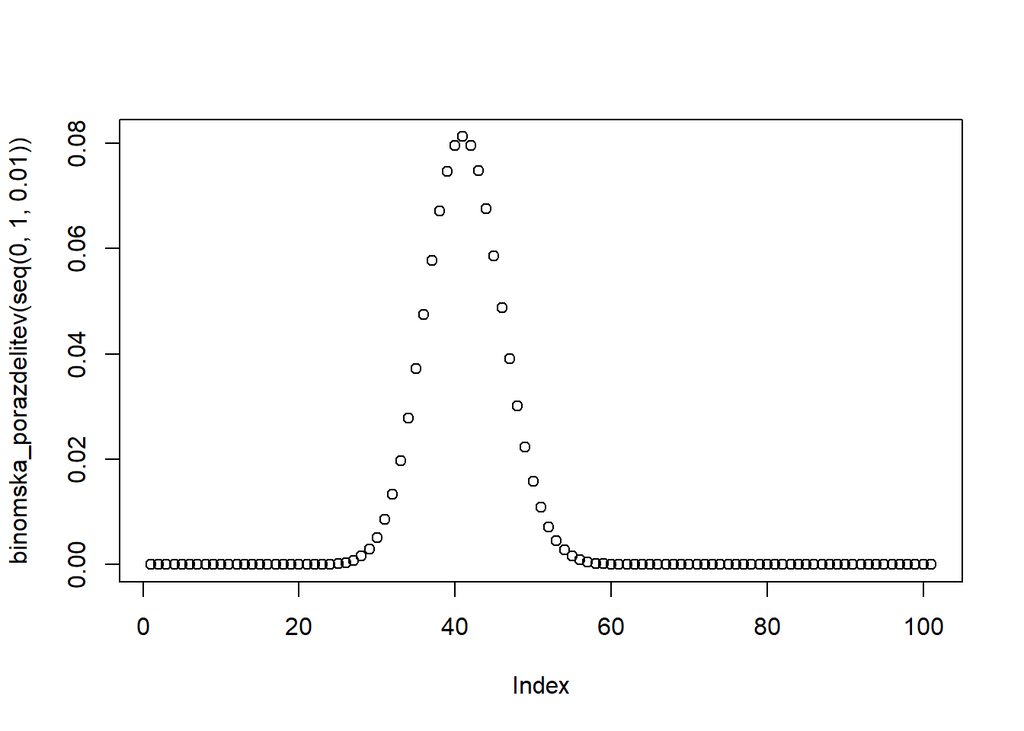

```r
plot(binomska_porazdelitev(seq(0, 1, 0.01)))
```

#### 2. Raziščite pomen ukazov pbinom, rbinom, qbinom, dbinom.

```r
#?dbinom
#?pbinom
#?rbinom
#?qbinom
```

*dbinom gives the density, pbinom gives the distribution function, qbinom gives the quantile function and rbinom generates random deviates.*

#### 3. S pomočjo ukaza rbinom kreirajte 100 naključnih števil na podlagi binomske porazdelitve in narišite histogram dobljenih podatkov.

```r
# rbinom(n, size, prob)

# 50 naključnih vrednosti iz binomske porazdelitve
(rb <- rbinom(100, 50, 0.8))
```

```
##   [1] 36 41 40 38 41 42 41 46 39 41 40 40 42 46 37 40 42 44 43 43 44 40 42 35 39
##  [26] 40 37 40 36 42 41 39 39 42 43 40 40 37 41 30 42 40 37 41 42 34 40 44 40 39
##  [51] 43 40 42 41 39 40 43 42 39 39 41 37 37 45 44 41 42 37 41 44 40 46 44 42 42
##  [76] 38 44 41 41 42 38 40 39 35 39 37 37 42 38 41 37 43 41 42 39 38 41 42 42 43
```

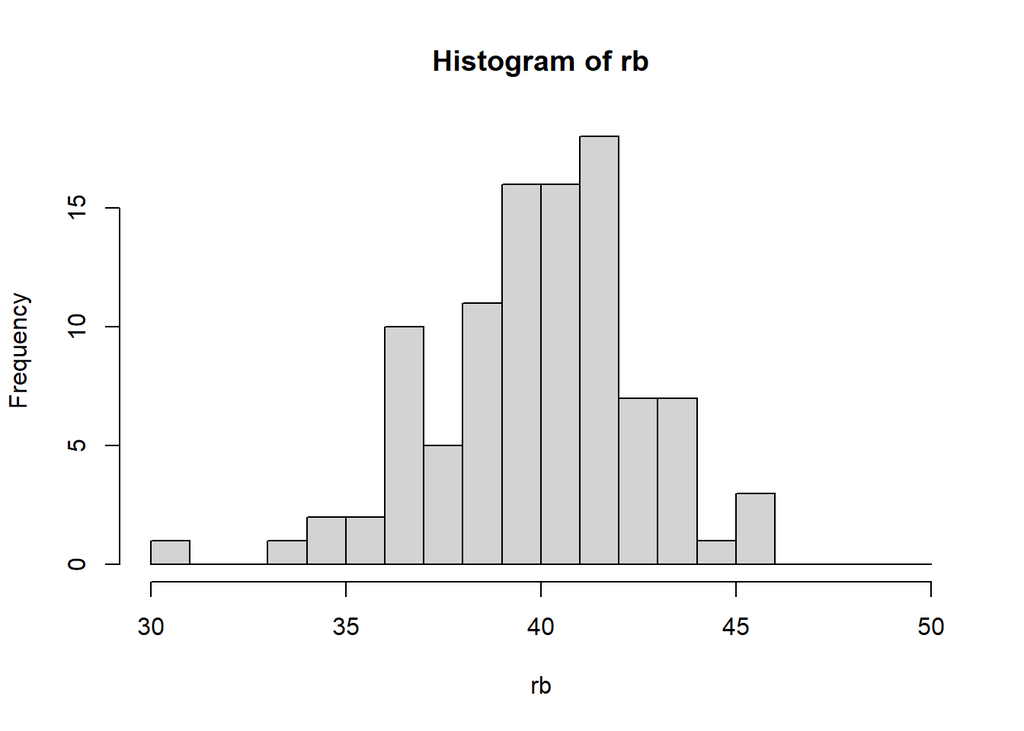

```r
hist(rb, breaks = seq(30, 50))
```

#### 4. S pomočjo ukaza dbinom preverite ali se vaš histogram ujema s teoretično fukcijo gostote.

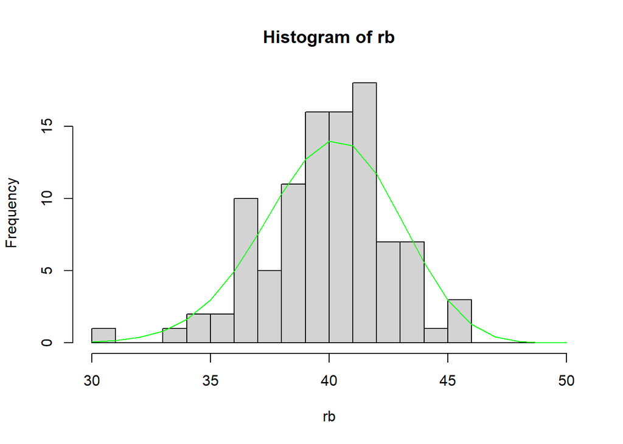

```r
sekv <- seq(30, 50)

hist(rb, breaks = sekv)
lines(sekv, dbinom(sekv, 50, 0.8) * 100, col = "green")
```

#### 6. Narišite graf fukcije, ki bo predstavljala $P(X \leq k)$ za nek določen delež k v odvisnosti od velikosti vzorca n za neko izbrano vrednost p.